# Permutation Statistics Analyses

Raphael Q. Gastrock

2024-07-26

This document contains permutation tests conducted for both ERP and TFR analyses

```r
source('ana/shared.R')
source('ana/learningRates.R')
source('ana/errorSizesERP.R')
source('ana/directionMoves.R')
source('ana/p3analysis.R')
source('ana/permutationTtest.R')
```

# ERP Analyses

## Early vs Late conditions

### Feedback-related Negativity (FRN)

This is time-locked to feedback onset. Analyses includes 10 fronto-central-parietal electrodes:

FCz, F3, Fz, F4, C3, Cz, C4, P3, Pz, P4

#### Comparison to aligned reaches (baseline)

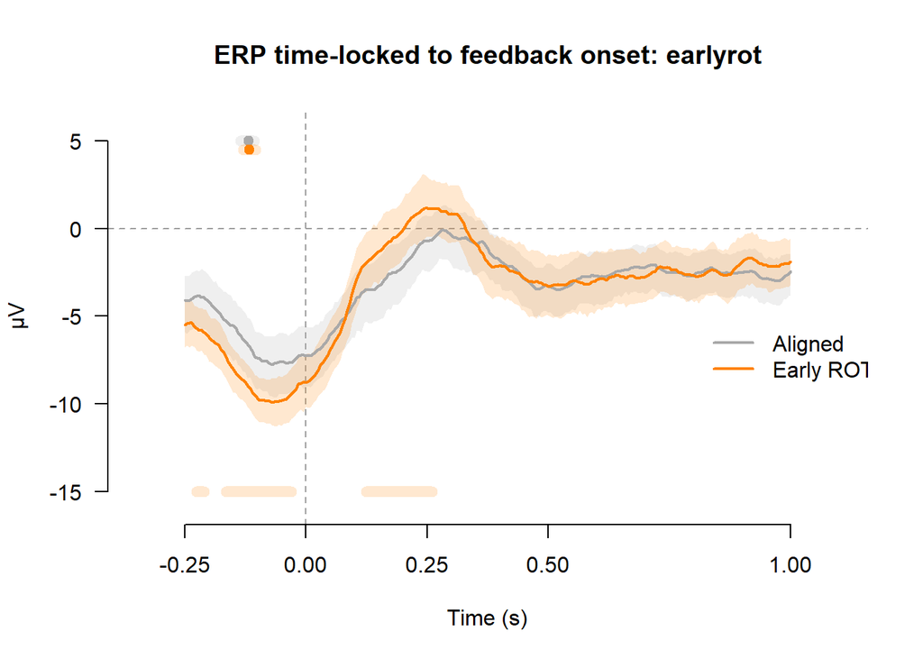

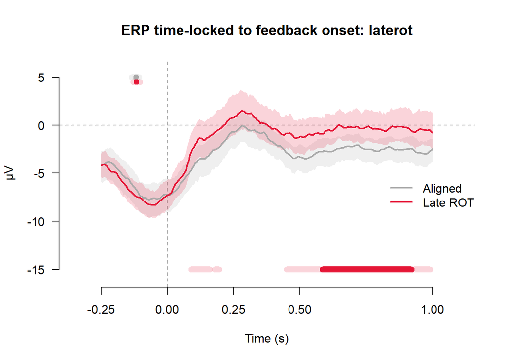

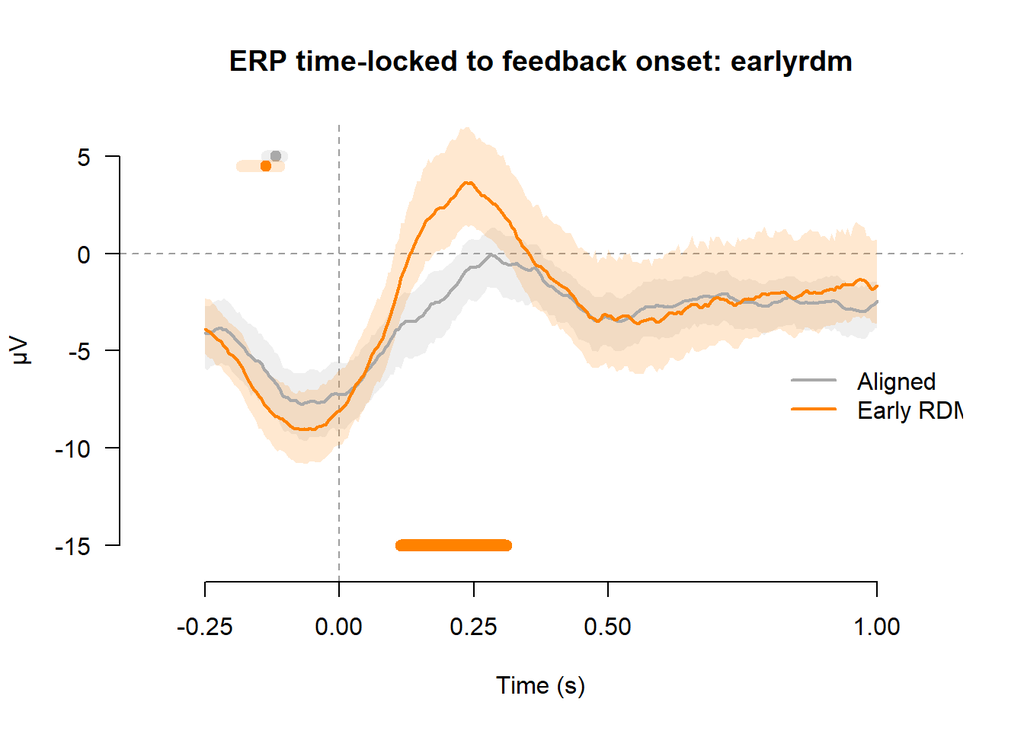

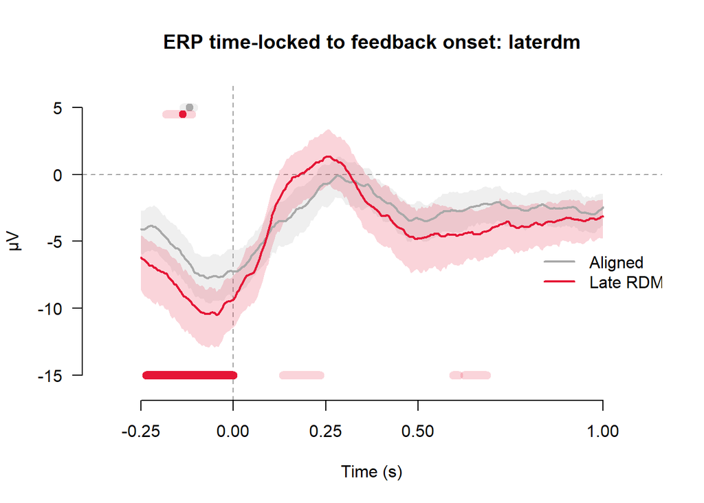

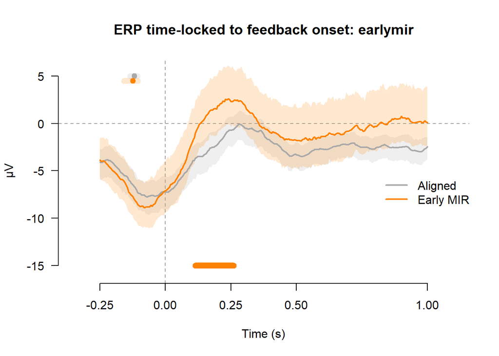

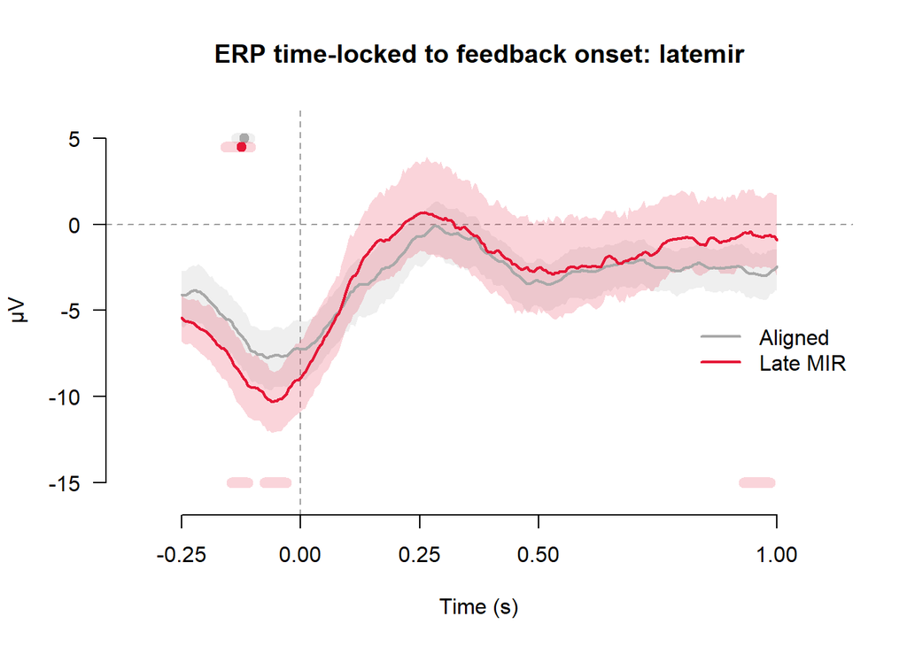

```r
plotPermTestEarlyLateERPs()
```

#### Comparison between early and late training

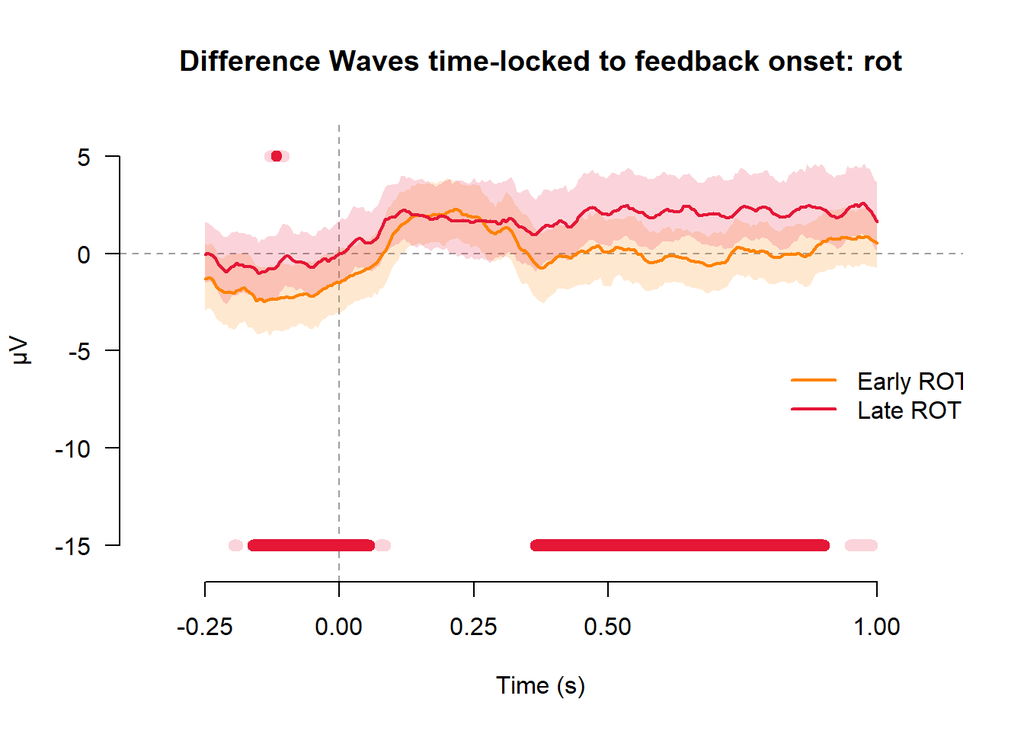

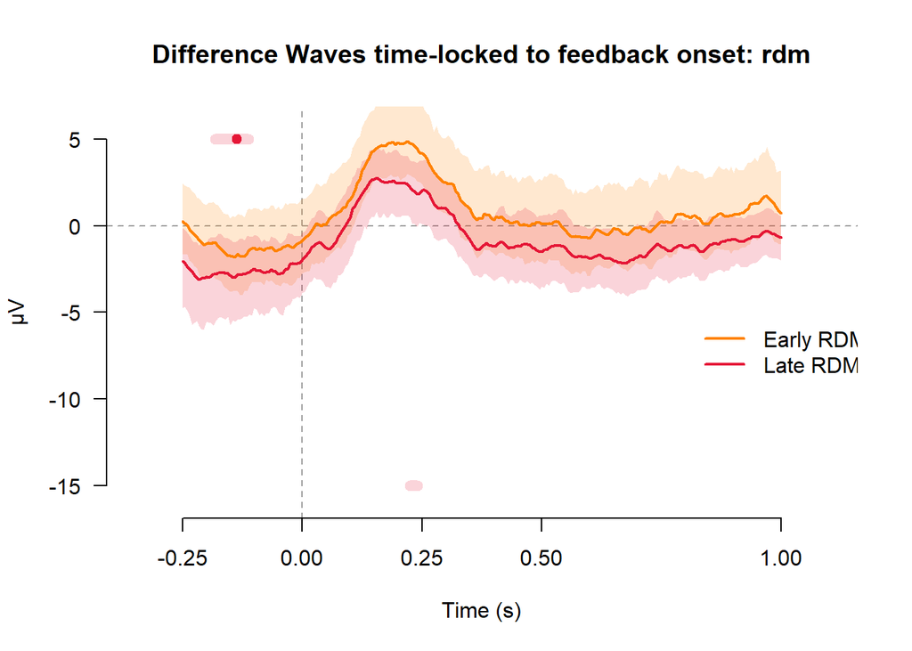

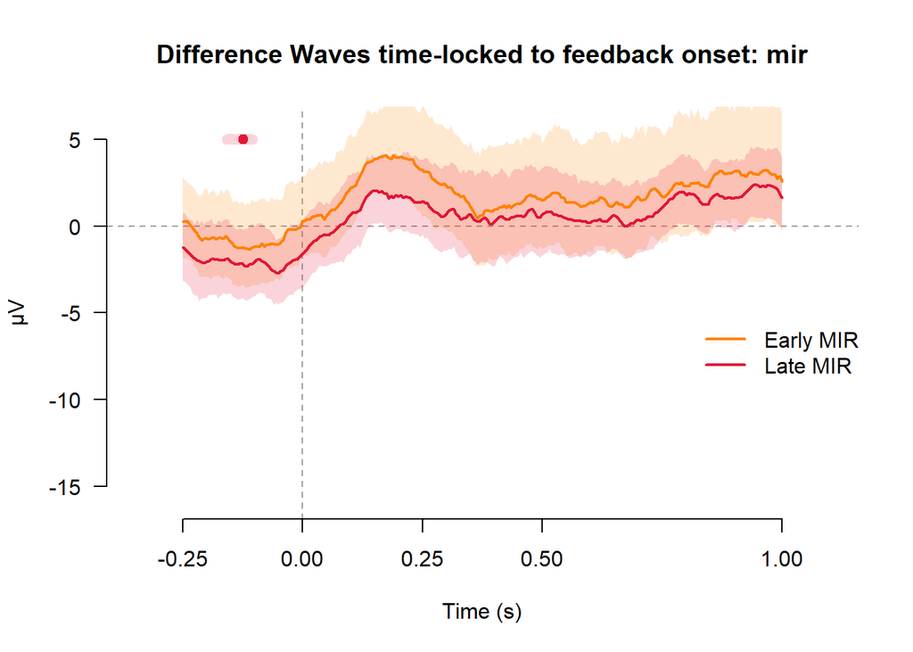

```r
plotPermTestEarlyLateDiffWaves()
```

#### Comparison across perturbation types

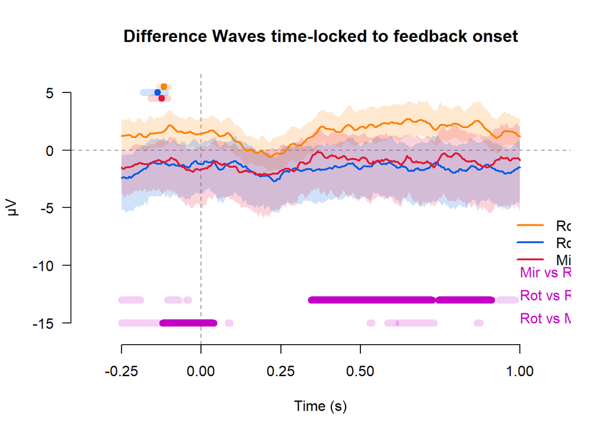

```r
plotPermTestPTypeEarlyLateDiffWaves()
```

### P3 component

This is also time-locked to feedback onset, but only considers electrodes along the midline:

FCz, Fz, Cz, Pz

#### Comparison to aligned reaches (baseline)

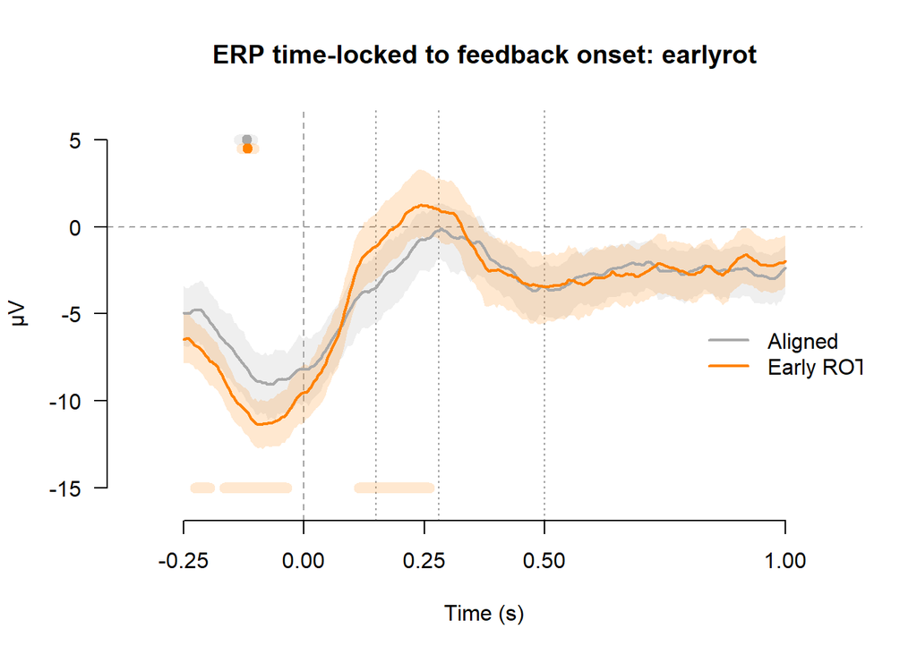

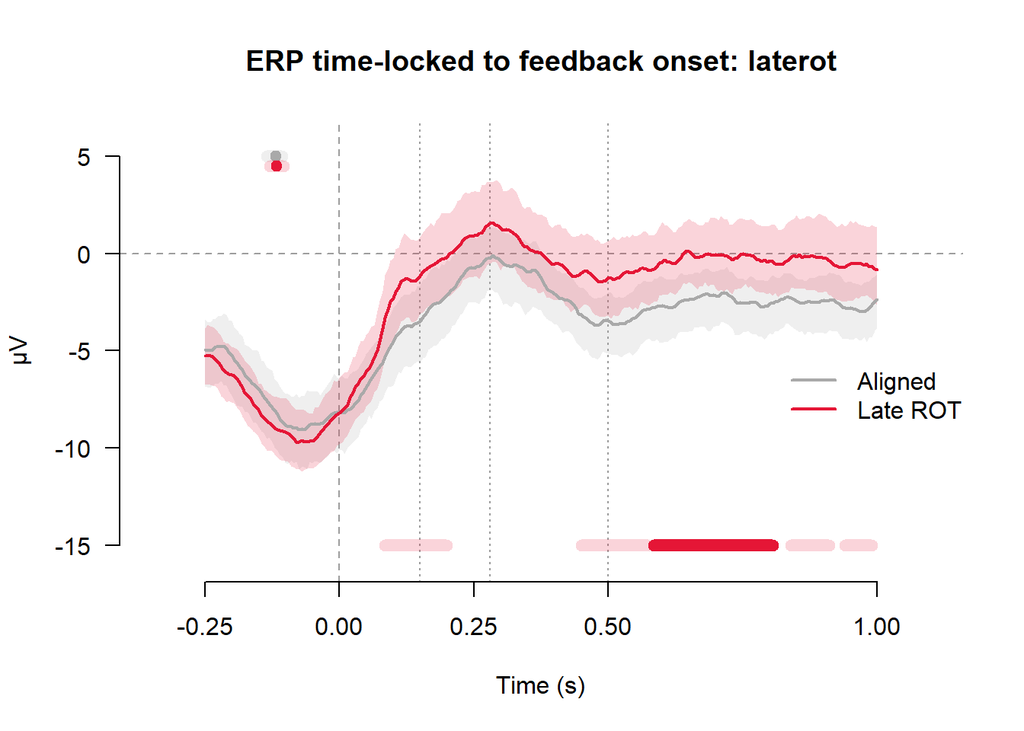

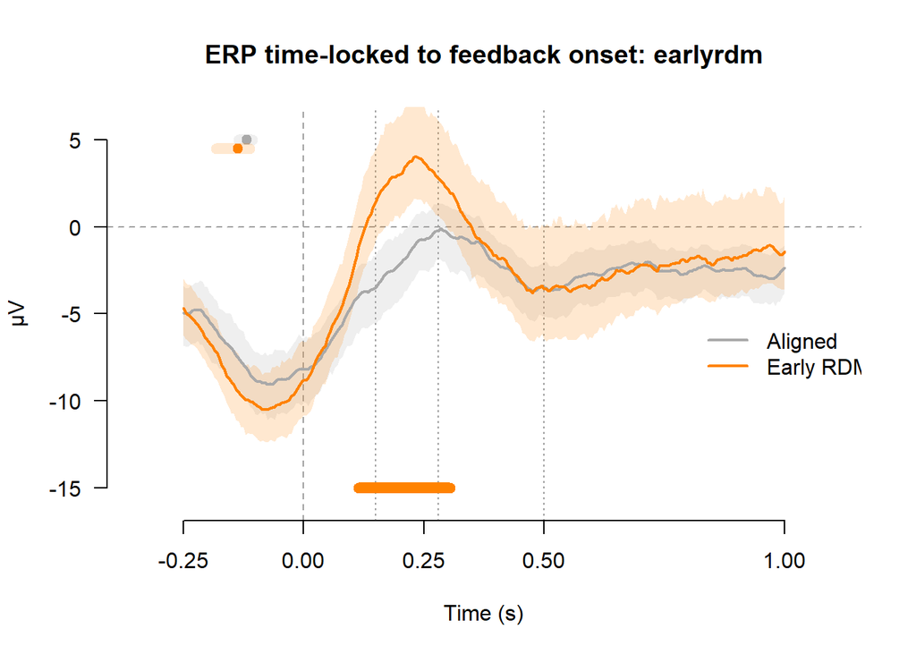

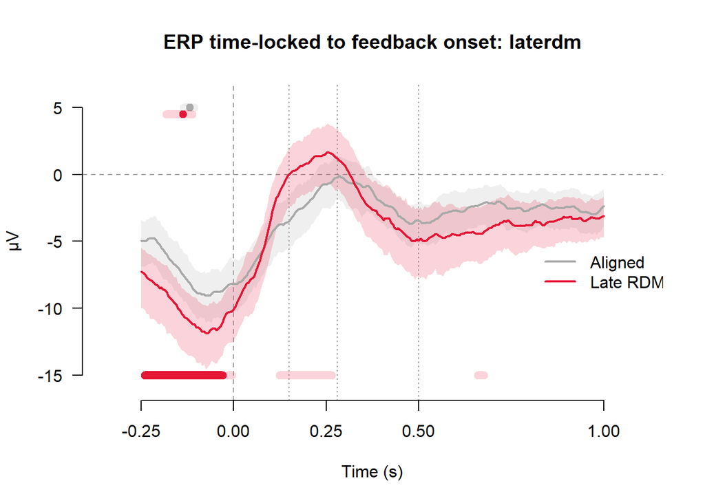

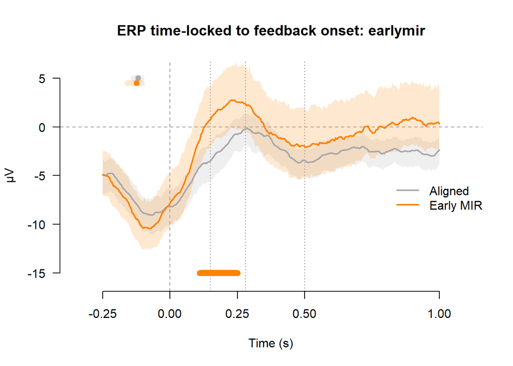

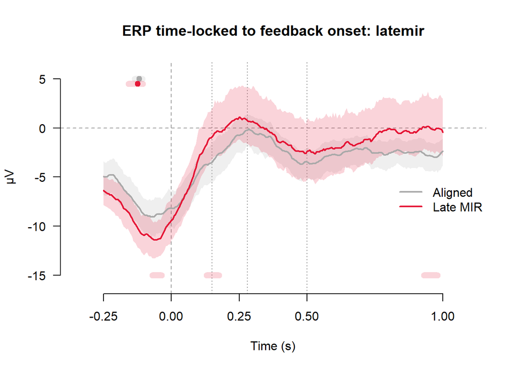

```r
plotPermTestEarlyLateP3()
```

#### Comparison between early and late training

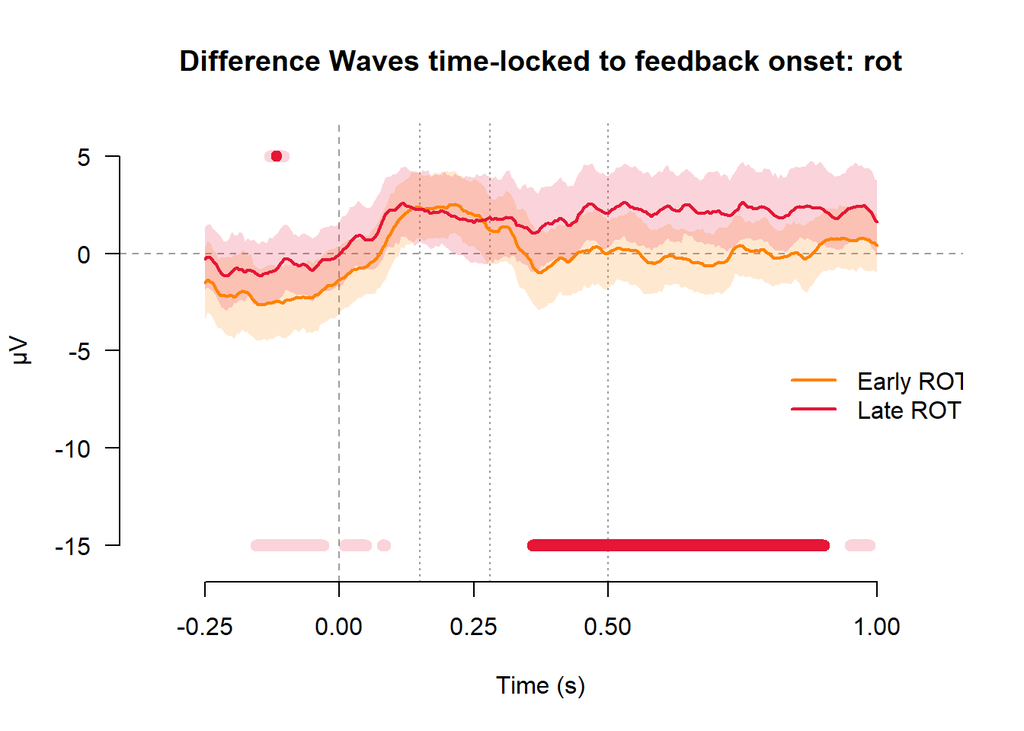

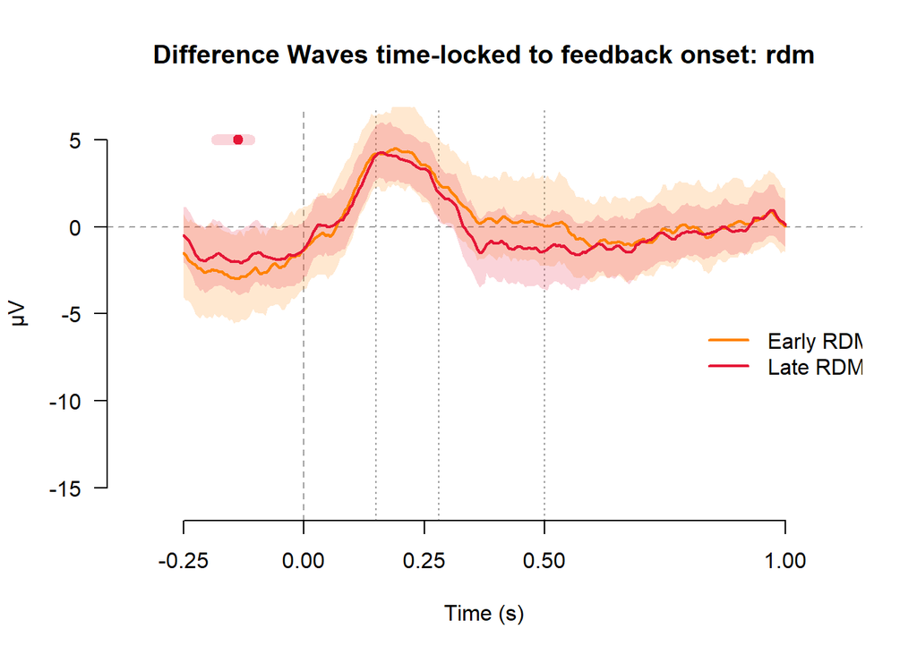

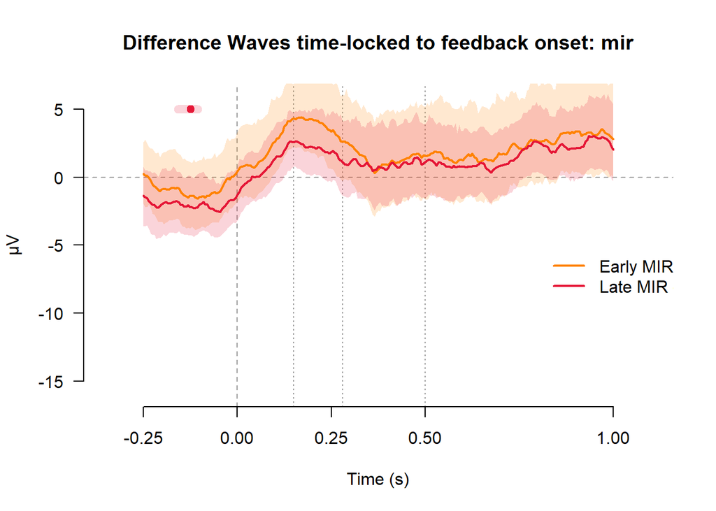

```r
plotPermTestEarlyLateDiffWavesP3()
```

#### Comparison across perturbation types

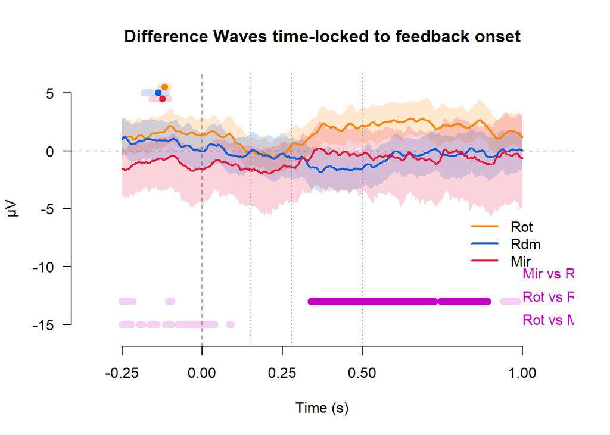

```r
plotPermTestPTypeEarlyLateDiffWavesP3()
```

### Lateralized Readiness Potential (LRP)

This is time-locked to the go signal onset, which is 1 second after target onset. Analyses includes C3 and C4 electrodes, and considers only reaches to the left or right side of the workspace.

#### Comparison to aligned reaches (baseline)

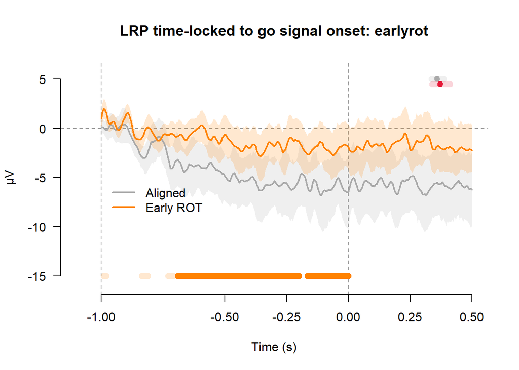

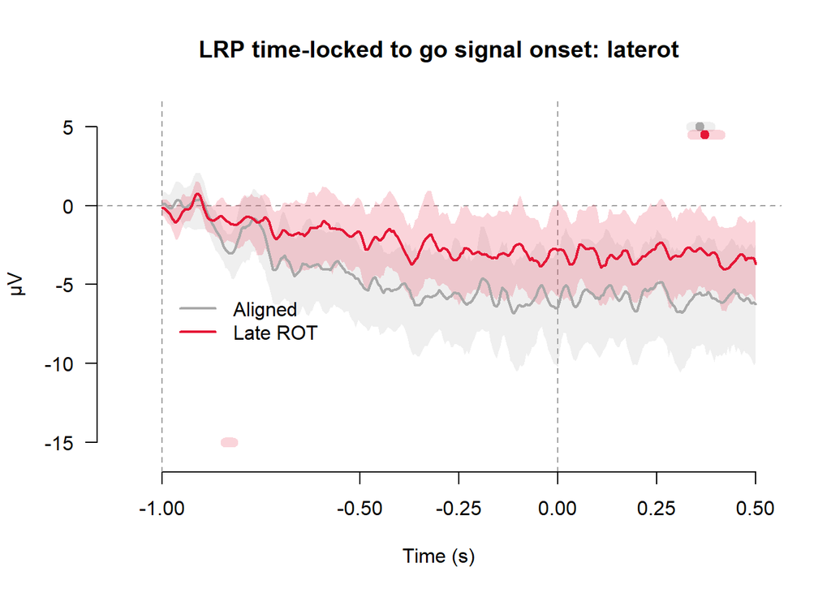

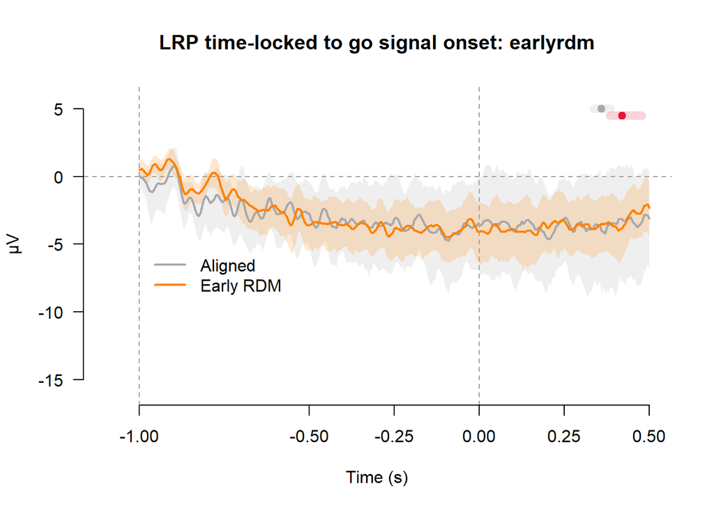

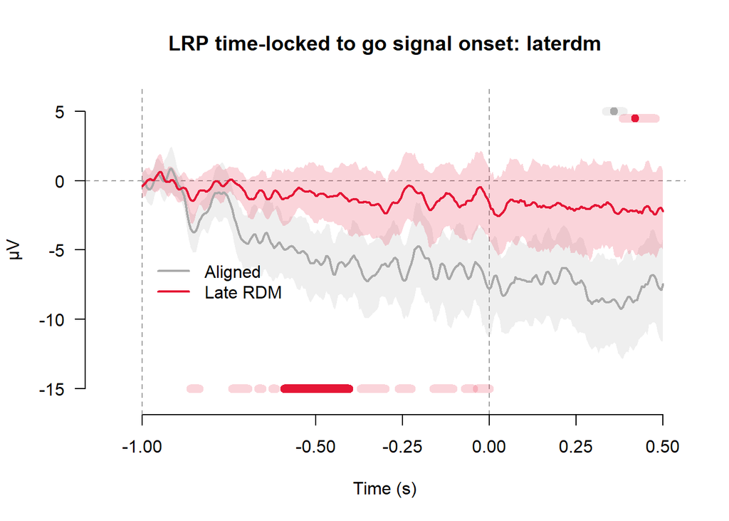

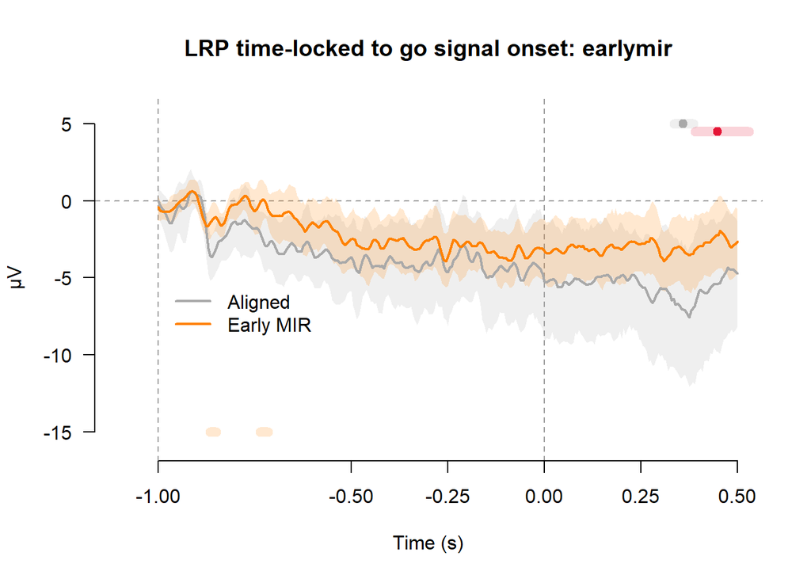

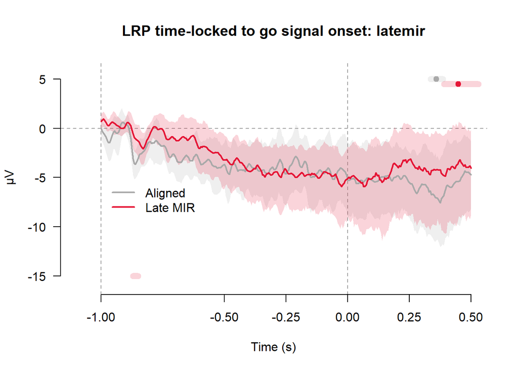

```r
plotPermTestEarlyLateLRPs()
```

#### Comparison between early and late training

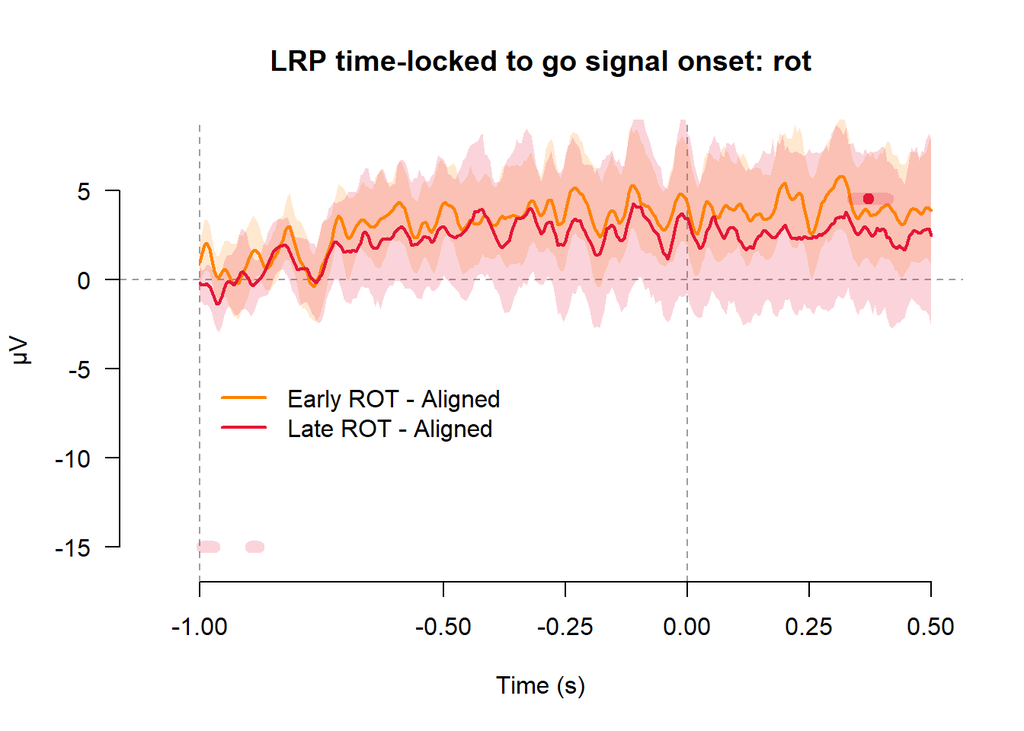

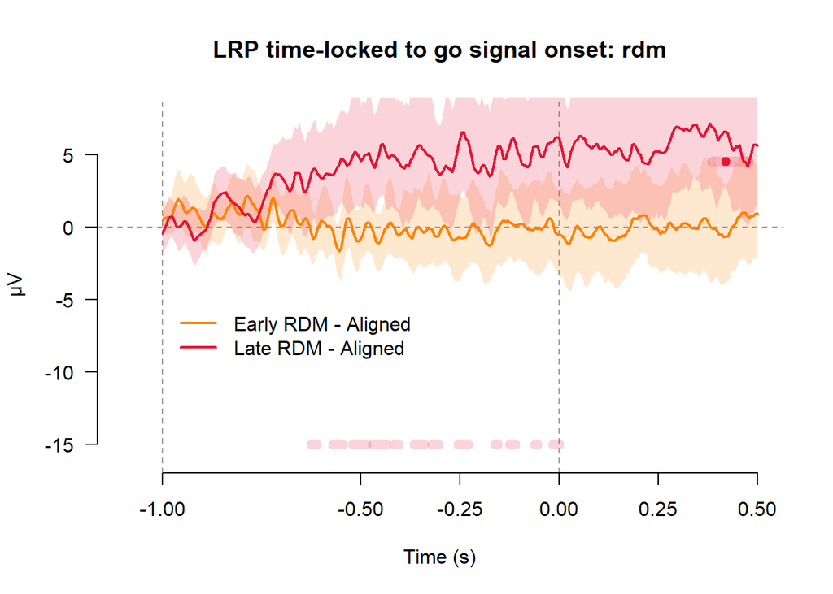

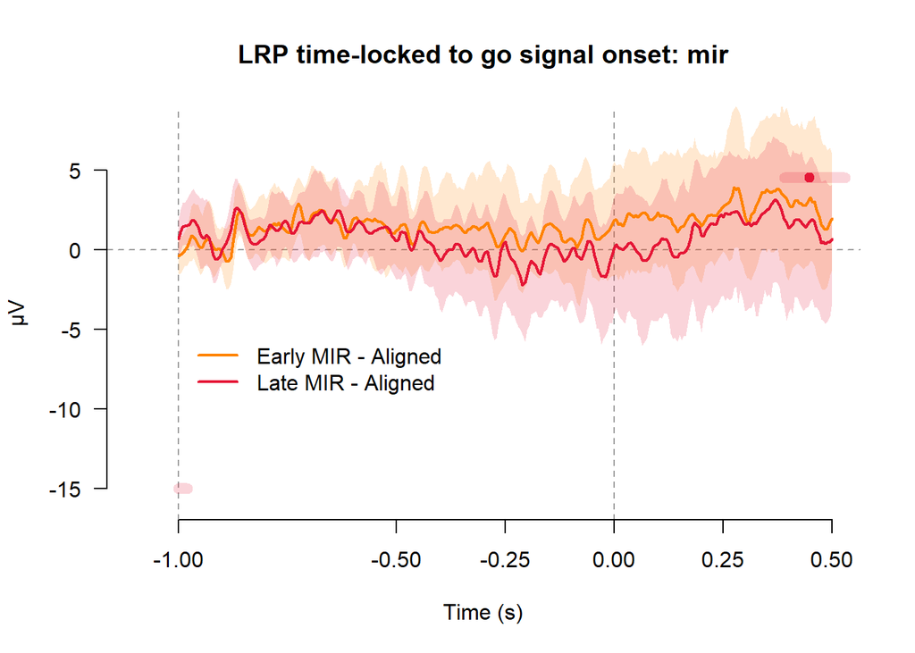

```r
plotPermTestEarlyLateLRPDiffWaves()
```

#### Comparison across perturbation types

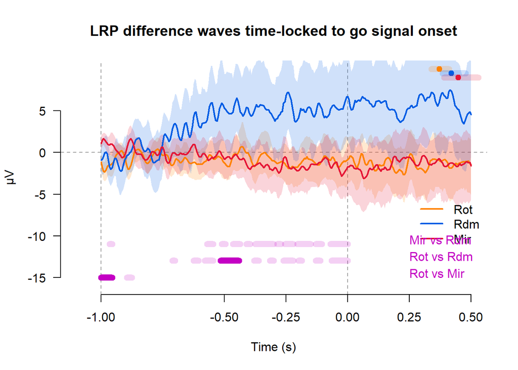

```r
plotPermTestPTypeEarlyLateLRPDiffWaves()
```